# Staatsoper Hamburg - Stück: Giacomo Puccini | La Fanciulla del West

[figure not shown]

Mi 26.03.2025, 19.30 - 22.10 Uhr | Großes Haus

[figure not shown]

[figure not shown]

[Karten kaufen](https://www.staatsoper-hamburg.de/de/service/karten/karten.php?performance=654&event=221610)

# La Fanciulla del West

**Einführung um 18.50 Uhr**

Kalifornien, 1850: Hunderttausende sind dem Goldrausch verfallen - und ein paar auch der Bardame Minnie, bei der sich versprengte Glückssuchende allabendlich treffen. Unter ihnen ist auch Sheriff Jack Rance. Doch Minnie verliebt sich in den Fremden Dick Johnson. Bald stellt sich heraus, dass Johnson ein gesuchter Räuber ist: Der Sheriff will ihn an den Strick und Minnie an sich bringen. Eine Partie Poker soll also über Dicks Leben entscheiden: Hat Minnie noch ein Ass im Ärmel?  
Puccini jedenfalls hatte mit seiner „Fanciulla“ eines, hielt das Stück sogar für sein Bestes: Nach Welterfolgen wie „La Bohème“ und „Madama Butterfly“ hatte er sich mit seinem „Italowestern“ neu erfunden. In „La Fanciulla del West“ verbinden sich Ragtime-Rhythmen, Anklänge an Gospel und die Musik der indianischen Ureinwohner mit italienischem Schmelz zu üppig orchestriertem Breitbandklang. Dieser verfehlte seine Wirkung auch 1910 bei der Uraufführung in der New Yorker Metropolitan Opera nicht. Und trotzdem fristete das Stück neben Puccinis großen Hits lange ein Schattendasein - bis die musikalischen Goldgräber loszogen...  
Inszenierung: Vincent Boussard  
Bühnenbild: Vincent Lemaire  
Kostüme: Christian Lacroix  
Licht: Guido Levi  
Premiere am: 01.02.2015

Eine Pause von ca. 25 Minuten nach dem ersten Akt

In italienischer Sprache mit deutschen Übertiteln  
Unterstützt durch die Stiftung zur Förderung der Hamburgischen Staatsoper

#### Trailer

[interactive chart not shown]

© theater-tv | Ulrich Bohn

Ort: Großes Haus, Dammtorstraße 28, 20354 Hamburg  
Preise: 7,00 EUR bis 119,00 EUR

[figure not shown]

#### Impressionen

[figure not shown]

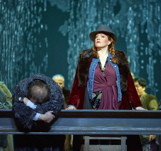

[figure not shown]

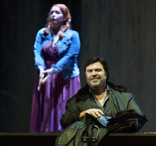

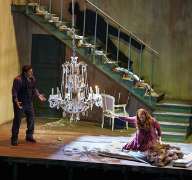

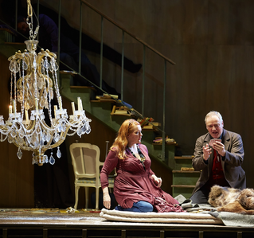

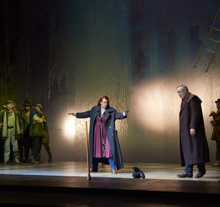

[figure not shown]

#### Unsere Empfehlungen

[figure not shown]

### [Rigoletto](https://www.staatsoper-hamburg.de/de/spielplan/stueck.php?AuffNr=221608)

So 23. Mär. 2025  
15.00 Uhr

[figure not shown]

### [Il trovatore](https://www.staatsoper-hamburg.de/de/spielplan/stueck.php?AuffNr=221619)

Do 27. Mär. 2025  
19.30 Uhr

[figure not shown]

### [Falstaff](https://www.staatsoper-hamburg.de/de/spielplan/stueck.php?AuffNr=221624)

Do 03. Apr. 2025  
19.30 Uhr

[figure not shown]

### [La Traviata](https://www.staatsoper-hamburg.de/de/spielplan/stueck.php?AuffNr=221623)

Di 08. Apr. 2025  
19.30 Uhr

[figure not shown]

### [Tosca](https://www.staatsoper-hamburg.de/de/spielplan/stueck.php?AuffNr=221677)

Do 22. Mai. 2025  
19.30 Uhr

[figure not shown]

### [Madama Butterfly](https://www.staatsoper-hamburg.de/de/spielplan/stueck.php?AuffNr=243542)

Do 16. Apr. 2026  
19.30 Uhr

[figure not shown]

### [Luisa Miller](https://www.staatsoper-hamburg.de/de/spielplan/stueck.php?AuffNr=243660)

So 24. Mai. 2026  
18.00 Uhr

[figure not shown]

[interactive chart not shown]